# Compare H3K27ac with gene expression (RNAseq)

last changed: 2023-08-29

# Gene Set Enrichment Analysis

## Data processing

First, the results from the enrichment analysis are loaded with the gene coding peaks within 1kb from the TSS. Here, a dataframe with one column containing the geneIDs and the other one with the corresponding cluster is required.

```r
> peak.list.cod.1kb <- readRDS("./../Enrichment_analysis/Data/peaks_H3ac_cod1kb.rds")
> lapply(peak.list.cod.1kb, head)
```

```
## $cluster_1
##     chr     start       end strand      genome_anno gene_symbol gene_entrez
## 1  chr2  58040368  58048461      . Promoter (<=1kb)        VRK2        7444
## 2  chr4 113977892 113980658      . Promoter (<=1kb)        ARSJ       79642
## 3 chr12 103929052 103930016      . Promoter (<=1kb)     HSP90B1        7184
## 4 chr12 103930337 103931619      . Promoter (<=1kb)     HSP90B1        7184
## 5  chr4 159282053 159285899      . Promoter (<=1kb)     RAPGEF2        9693
## 6  chr9  69375779  69378259      . Promoter (<=1kb)     ENTREP1        9413
##   distanceToTSS    transcriptId  geneId_ensembl
## 1             0 ENST00000412104 ENSG00000028116
## 2             0 ENST00000315366 ENSG00000180801
## 3           -91 ENST00000549334 ENSG00000166598
## 4             0 ENST00000680391 ENSG00000166598
## 5             0 ENST00000514565 ENSG00000109756
## 6             0 ENST00000645516 ENSG00000135063
```

[output cut: 32 more lines]

```r
> names(peak.list.cod.1kb) <- 1:3
> df.peaks <- melt(peak.list.cod.1kb, variable.factor = T)
> colnames(df.peaks)[11] <- "cluster"
> cluster <- select(df.peaks, cluster, geneId_ensembl)
>
> head(cluster)
```

```
##   cluster  geneId_ensembl
## 1       1 ENSG00000028116
## 2       1 ENSG00000180801
## 3       1 ENSG00000166598
## 4       1 ENSG00000166598
## 5       1 ENSG00000109756
## 6       1 ENSG00000135063
```

Next, the RNAseq results were loaded and transformed into a named vector.

```r
> results <- read.delim("./Data/res_RNAseq.txt")
>
> gene.list <- results$log2FoldChange
> names(gene.list) <- results$ensembl_gene_id
```

These results were then filtered for only protein coding genes.

```r
> results.cod <- results[which(results$gene_biotype == "protein_coding"), ]
>
> gene.list.cod <- results.cod$log2FoldChange
> names(gene.list.cod) <- results.cod$ensembl_gene_id
```

Lastly, the log2 fold change and the adjusted p-values were used to calculate a robust sorting score for the RNAseq gene list.

```r
> log2fold.adj.p <- results.cod$log2FoldChange * (-log10(results.cod$padj))
> log2fold.adj.p[is.na(log2fold.adj.p)] <- 0
> names(log2fold.adj.p) <- results.cod$ensembl_gene_id
> log2fold.adj.p <- sort(log2fold.adj.p, decreasing = T)
```

The sorted vector when then used to perform a GSEA.

```r
> gse.adj.p <- GSEA(log2fold.adj.p, TERM2GENE = cluster, pvalueCutoff = 1, pAdjustMethod = "BH", maxGSSize = 2000)
>
> gse.adj.p@result[, -11]
```

```
##   ID Description setSize enrichmentScore        NES     pvalue   p.adjust
## 2  2           2     449      -0.7594815 -1.4812420 0.01356789 0.04070368
## 3  3           3    1617       0.5336334  1.0105308 0.45923261 0.68884892
## 1  1           1     323       0.4510469  0.7650406 0.88345324 0.88345324
##       qvalue rank                  leading_edge
## 2 0.02856399  490   tags=6%, list=2%, signal=6%
## 3 0.48340275 1241 tags=12%, list=6%, signal=12%
## 1 0.61996718 1232   tags=7%, list=6%, signal=7%
```

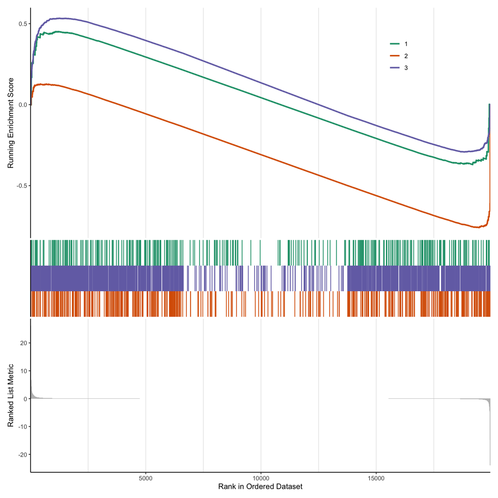

```r
> col <- brewer.pal(n = 8, name = "Dark2")
> gseaplot2(gse.adj.p, geneSetID = 1:3, color = col[1:3])
```

# Correlation between H3K27ac and RNAseq

## Data processing

First, the data (rlog-transformed DESeq data sets) were loaded for H3k27ac and RNAseq. Here, the sample for Exp2 at 0 hpi was removed, because it was identified as an outlier in a PCA (not shown).

```r
> #RNAseq:
> load(file = "./Data/rlog_RNAseq.rda")
>
> m.RNAseq <- assay(rld)
> info.RNAseq <- data.frame(colData(rld))
> info.RNAseq <- filter(info.RNAseq, name != "Exp2_0")
> m.RNAseq <- m.RNAseq[, info.RNAseq$name]
>
> head(m.RNAseq)
```

[output not shown]

```r
> paged_table(info.RNAseq)
```

|  | ID | name | condition | replica | Time | sizeFactor |
| --- | --- | --- | --- | --- | --- | --- |
| Exp1_05h | Exp1_05h | Exp1_05h | 0.5hpi | R1 | 0.5 | 0.8762770 |
| Exp1_0 | Exp1_0 | Exp1_0 | 0hpi | R1 | 0 | 1.0771883 |
| Exp1_1h | Exp1_1h | Exp1_1h | 1hpi | R1 | 1 | 0.9178595 |
| Exp1_2h | Exp1_2h | Exp1_2h | 2hpi | R1 | 2 | 0.9673782 |
| Exp1_4h | Exp1_4h | Exp1_4h | 4hpi | R1 | 4 | 0.6546086 |
| Exp2_05h | Exp2_05h | Exp2_05h | 0.5hpi | R2 | 0.5 | 0.8440820 |
| Exp2_1h | Exp2_1h | Exp2_1h | 1hpi | R2 | 1 | 2.8553225 |
| Exp2_2h | Exp2_2h | Exp2_2h | 2hpi | R2 | 2 | 1.0124080 |
| Exp2_4h | Exp2_4h | Exp2_4h | 4hpi | R2 | 4 | 0.6864945 |

```r
> #H3K27ac:
> load(file = "./../Clustering/Data/rlog_H3K27ac.rda")
>
> m.H3ac <- assay(rlog.heat)
> info.H3ac <- data.frame(colData(rlog.heat))
>
> head(m.H3ac)
```

```
##                          U2OS31_Rep3_T0h U2OS31_Rep2_T0h U2OS31_Rep1_T0h
## chr14:64840548-64843743         8.114822        7.673740        8.023597
## chr14:64844047-64844598         5.168237        4.901399        5.314293
## chr14:64879344-64880265         6.278250        6.393489        6.344536
## chr14:34718145-34719716         6.403472        6.338191        6.499216
## chr1:116508159-116509891        6.745025        6.609159        6.927211
## chr20:43656766-43658787         8.693456        8.685128        8.609964
##                          U2OS31_Rep3_T1h U2OS31_Rep2_T1h U2OS31_Rep1_T1h
## chr14:64840548-64843743         7.888180        7.806799        7.795138
## chr14:64844047-64844598         5.214389        4.934340        5.385935
## chr14:64879344-64880265         6.553256        6.365019        6.319149
## chr14:34718145-34719716         6.163944        6.256559        6.683269
## chr1:116508159-116509891        6.762316        6.537329        6.582979
## chr20:43656766-43658787         8.618728        8.748419        8.676542
##                          U2OS31_Rep2_T2h U2OS31_Rep1_T2h U2OS31_Rep2_T4h
## chr14:64840548-64843743         7.877125        8.084551        8.074168
## chr14:64844047-64844598         5.038682        4.993397        5.357572
## chr14:64879344-64880265         5.827899        6.442181        5.547984
## chr14:34718145-34719716         6.008420        6.339056        6.229904
## chr1:116508159-116509891        6.957996        6.488052        7.287550
## chr20:43656766-43658787         8.618982        8.713472        8.533015
##                          U2OS31_Rep1_T4h U2OS33_Rep3_T0h U2OS33_Rep2_T0h
## chr14:64840548-64843743         8.376569        8.633430        8.508029
## chr14:64844047-64844598         5.646808        5.414160        4.869788
## chr14:64879344-64880265         6.043889        6.885362        7.056070
## chr14:34718145-34719716         6.205086        6.247230        6.399628
## chr1:116508159-116509891        6.700267        7.295421        7.102558
## chr20:43656766-43658787         8.479299        8.646970        8.900604
##                          U2OS33_Rep1_T0h U2OS33_Rep3_T1h U2OS33_Rep2_T1h
## chr14:64840548-64843743         8.417293        8.205261        7.877607
## chr14:64844047-64844598         5.558584        5.199403        4.726920
## chr14:64879344-64880265         6.687126        7.233049        7.264508
## chr14:34718145-34719716         6.870802        6.314254        6.400750
## chr1:116508159-116509891        6.867823        6.978202        6.953522
## chr20:43656766-43658787         8.736049        8.653763        8.955693
##                          U2OS33_Rep1_T1h U2OS33_Rep3_T2h U2OS33_Rep2_T2h
## chr14:64840548-64843743         7.874708        8.396817        8.025447
## chr14:64844047-64844598         5.251940        5.420109        4.983230
## chr14:64879344-64880265         7.297511        6.202167        6.636320
## chr14:34718145-34719716         6.767086        6.099985        6.372380
## chr1:116508159-116509891        6.797574        7.496190        7.285854
## chr20:43656766-43658787         8.799718        8.465556        8.754602
##                          U2OS33_Rep1_T2h U2OS33_Rep3_T4h U2OS33_Rep2_T4h
## chr14:64840548-64843743         7.987048        8.869853        8.889043
## chr14:64844047-64844598         4.992402        5.907303        5.506129
## chr14:64879344-64880265         6.909849        6.320917        6.425528
## chr14:34718145-34719716         6.606198        6.416040        5.996964
## chr1:116508159-116509891        7.172071        7.536092        7.469608
## chr20:43656766-43658787         8.778998        8.454756        8.749145
##                          U2OS33_Rep1_T4h
## chr14:64840548-64843743         8.613300
## chr14:64844047-64844598         5.726578
## chr14:64879344-64880265         6.562254
## chr14:34718145-34719716         6.261731
## chr1:116508159-116509891        7.176942
## chr20:43656766-43658787         8.628161
```

```r
> paged_table(info.H3ac)
```

|  | X | construct | replica | time | sizeFactor |
| --- | --- | --- | --- | --- | --- |
| U2OS31_Rep3_T0h | X.U2OS31_Rep3_T0h. | U2OS31 | rep3 | 0 | 1.3968310 |
| U2OS31_Rep2_T0h | X.U2OS31_Rep2_T0h. | U2OS31 | rep2 | 0 | 0.9460993 |
| U2OS31_Rep1_T0h | X.U2OS31_Rep1_T0h. | U2OS31 | rep1 | 0 | 0.9696657 |
| U2OS31_Rep3_T1h | X.U2OS31_Rep3_T1h. | U2OS31 | rep3 | 1 | 1.3733868 |
| U2OS31_Rep2_T1h | X.U2OS31_Rep2_T1h. | U2OS31 | rep2 | 1 | 1.3540956 |
| U2OS31_Rep1_T1h | X.U2OS31_Rep1_T1h. | U2OS31 | rep1 | 1 | 1.3395030 |
| U2OS31_Rep2_T2h | X.U2OS31_Rep2_T2h. | U2OS31 | rep2 | 2 | 1.3782190 |
| U2OS31_Rep1_T2h | X.U2OS31_Rep1_T2h. | U2OS31 | rep1 | 2 | 0.9700746 |
| U2OS31_Rep2_T4h | X.U2OS31_Rep2_T4h. | U2OS31 | rep2 | 4 | 1.1987809 |
| U2OS31_Rep1_T4h | X.U2OS31_Rep1_T4h. | U2OS31 | rep1 | 4 | 1.0889653 |

[output cut: 12 more lines]

Since the two experiments have different time points, the matrices need to be filtered for the required time points. Then, the median over the replicates can be calculated. For the H3K27ac the matrix was additionally separated by construct.

```r
> times <- c(0, 1, 2, 4)
>
> # RNAseq:
> m.RNAseq.median <- matrix(data = NA, ncol = 4, nrow = nrow(m.RNAseq))
> rownames(m.RNAseq.median) <- rownames(m.RNAseq)
> colnames(m.RNAseq.median) <- c("T0h", "T1h", "T2h", "T4h")
>
> for (t in 1:4) {
+   ind <- which(info.RNAseq[, "Time"] == times[t])
+   if (t == 1)
+     medians <- m.RNAseq[, ind]
+   else
+     medians <- apply(m.RNAseq[,  ind], 1, median)
+   m.RNAseq.median[, t] <- medians
+ }
>
> saveRDS(m.RNAseq.median, "./Data/m_RNAseq_median.rds")
>
> head(m.RNAseq.median)
```

```
##                       T0h       T1h       T2h       T4h
## ENSG00000243485  0.000000  0.000000  0.000000  0.000000
## ENSG00000237613  0.000000  0.000000  0.000000  0.000000
## ENSG00000186092  0.000000  0.000000  0.000000  0.000000
## ENSG00000238009 -2.129442 -2.131484 -2.129933 -2.124332
## ENSG00000239945  0.000000  0.000000  0.000000  0.000000
## ENSG00000241599  0.000000  0.000000  0.000000  0.000000
```

```r
> # H3K27ac:
> ind.H3.1 <- which(info.H3ac$construct == "U2OS31")
> ind.H3.3 <- which(info.H3ac$construct == "U2OS33")
>
> m.H3.1ac <- m.H3ac[ ,ind.H3.1]
> m.H3.3ac <- m.H3ac[ ,ind.H3.3]
>
> m.H3.1ac.median <- matrix(data = NA, ncol = 4, nrow = nrow(m.H3.1ac))
> rownames(m.H3.1ac.median) <- rownames(m.H3.1ac)
> colnames(m.H3.1ac.median) <- c("T0h", "T1h", "T2h", "T4h")
>
> m.H3.3ac.median <- m.H3.1ac.median
>
> for (t in 1:4) {
+   t.0.H3.1 <- which(info.H3ac[ind.H3.1, "time"] == times[t])
+   medians <- apply(m.H3.1ac[,  t.0.H3.1], 1, median)
+   m.H3.1ac.median[, t] <- medians
+ }
>
> for (t in 1:4) {
+   t.0.H3.3 <- which(info.H3ac[ind.H3.3, "time"] == times[t])
+   medians <- apply(m.H3.3ac[,  t.0.H3.3], 1, median)
+   m.H3.3ac.median[, t] <- medians
+ }
>
> saveRDS(m.H3.1ac.median, "./Data/m_H3.1K27ac_median.rds")
> saveRDS(m.H3.3ac.median, "./Data/m_H3.3K27ac_median.rds")
>
> head(m.H3.1ac.median)
```

```
##                               T0h      T1h      T2h      T4h
## chr14:64840548-64843743  8.023597 7.806799 7.980838 8.225369
## chr14:64844047-64844598  5.168237 5.214389 5.016040 5.502190
## chr14:64879344-64880265  6.344536 6.365019 6.135040 5.795937
## chr14:34718145-34719716  6.403472 6.256559 6.173738 6.217495
## chr1:116508159-116509891 6.745025 6.582979 6.723024 6.993908
## chr20:43656766-43658787  8.685128 8.676542 8.666227 8.506157
```

```r
> head(m.H3.3ac.median)
```

```
##                               T0h      T1h      T2h      T4h
## chr14:64840548-64843743  8.508029 7.877607 8.025447 8.869853
## chr14:64844047-64844598  5.414160 5.199403 4.992402 5.726578
## chr14:64879344-64880265  6.885362 7.264508 6.636320 6.425528
## chr14:34718145-34719716  6.399628 6.400750 6.372380 6.261731
## chr1:116508159-116509891 7.102558 6.953522 7.285854 7.469608
## chr20:43656766-43658787  8.736049 8.799718 8.754602 8.628161
```

Further, the annotated peak list is required and needs to be sorted and filtered to only contain genes/peaks contained in both experiments.

```r
> peaks.cod <- readRDS("./../Enrichment_analysis/Data/peaks_H3ac_cod1kb.rds")
> peaks <- rbind(peaks.cod[[1]], peaks.cod[[2]], peaks.cod[[3]])
> peaks <- mutate(peaks, peak_pos = paste0(peaks$chr, ":", peaks$start, "-", peaks$end))
>
> paged_table(peaks)
```

| chr | start | end | strand | genome_anno | gene_symbol | gene_entrez | distanceToTSS | transcriptId | geneId_ensembl | peak_pos |
| --- | --- | --- | --- | --- | --- | --- | --- | --- | --- | --- |
| chr2 | 58040368 | 58048461 | . | Promoter (<=1kb) | VRK2 | 7444 | 0 | ENST00000412104 | ENSG00000028116 | chr2:58040368-58048461 |
| chr4 | 113977892 | 113980658 | . | Promoter (<=1kb) | ARSJ | 79642 | 0 | ENST00000315366 | ENSG00000180801 | chr4:113977892-113980658 |
| chr12 | 103929052 | 103930016 | . | Promoter (<=1kb) | HSP90B1 | 7184 | -91 | ENST00000549334 | ENSG00000166598 | chr12:103929052-103930016 |
| chr12 | 103930337 | 103931619 | . | Promoter (<=1kb) | HSP90B1 | 7184 | 0 | ENST00000680391 | ENSG00000166598 | chr12:103930337-103931619 |
| chr4 | 159282053 | 159285899 | . | Promoter (<=1kb) | RAPGEF2 | 9693 | 0 | ENST00000514565 | ENSG00000109756 | chr4:159282053-159285899 |
| chr9 | 69375779 | 69378259 | . | Promoter (<=1kb) | ENTREP1 | 9413 | 0 | ENST00000645516 | ENSG00000135063 | chr9:69375779-69378259 |
| chr21 | 35046170 | 35049885 | . | Promoter (<=1kb) | RUNX1 | 861 | 0 | ENST00000437180 | ENSG00000159216 | chr21:35046170-35049885 |
| chr21 | 35050119 | 35052056 | . | Promoter (<=1kb) | RUNX1 | 861 | -775 | ENST00000300305 | ENSG00000159216 | chr21:35050119-35052056 |
| chr17 | 48601172 | 48605550 | . | Promoter (<=1kb) | HOXB6 | 3216 | 0 | ENST00000225648 | ENSG00000108511 | chr17:48601172-48605550 |
| chr1 | 101024869 | 101026937 | . | Promoter (<=1kb) | DPH5 | 51611 | 0 | ENST00000370105 | ENSG00000117543 | chr1:101024869-101026937 |

[output cut: 2460 more lines]

```r
> peaks.RNAseq <- intersect(peaks$geneId_ensembl, rownames(m.RNAseq))
>
> peaks.both <- peaks[which(peaks$geneId_ensembl %in% peaks.RNAseq), ]
>
> m.H3.1ac.med.cod <- m.H3.1ac.median[peaks.both$peak_pos, ]
> m.H3.3ac.med.cod <- m.H3.3ac.median[peaks.both$peak_pos, ]
> m.RNAseq.med.cod <- m.RNAseq.median[peaks.both$geneId_ensembl, ]
```

Next, the correlation was calculated for H3.1/H3.3 K27ac and RNAseq, as follows:

```r
> # correlation for H3.1K27ac and RNAseq
> cor.H3.1ac.RNAseq <- c()
>
> for (i in 1:nrow(peaks.both)) {
+   curr.corr <- cor(m.H3.1ac.med.cod[i, ], m.RNAseq.med.cod[i, ], method = "pearson")
+   cor.H3.1ac.RNAseq <- c(cor.H3.1ac.RNAseq, curr.corr)
+ }
> names(cor.H3.1ac.RNAseq) <- rownames(m.RNAseq.med.cod)
>
> head(cor.H3.1ac.RNAseq)
```

```
## ENSG00000028116 ENSG00000180801 ENSG00000166598 ENSG00000166598 ENSG00000109756
##     -0.61185280     -0.31710258     -0.03892641      0.25830473      0.86149735
## ENSG00000135063
##      0.64762063
```

```r
> # correlation for H3.3K27ac and RNAseq
> cor.H3.3ac.RNAseq <- c()
>
> for (i in 1:nrow(peaks.both)) {
+   curr.corr <- cor(m.H3.3ac.med.cod[i, ], m.RNAseq.med.cod[i, ], method = "pearson")
+   cor.H3.3ac.RNAseq <- c(cor.H3.3ac.RNAseq, curr.corr)
+ }
> names(cor.H3.3ac.RNAseq) <- rownames(m.RNAseq.med.cod)
>
> head(cor.H3.3ac.RNAseq)
```

```
## ENSG00000028116 ENSG00000180801 ENSG00000166598 ENSG00000166598 ENSG00000109756
##      -0.4703882      -0.4146449       0.1895379       0.4569094       0.5367628
## ENSG00000135063
##       0.7906112
```

To plot the correlation between H3K27ac and RNAseq for each cluster the data was transformed into a dataframe, containing the required factors/values. The correlation was then plotted using `geom_density`.

```r
> cor.H3ac.RNAseq.NAs <- data.frame(U2OS31 = cor.H3.1ac.RNAseq,
+                                   U2OS33 = cor.H3.3ac.RNAseq,
+                                   gene = rownames(m.RNAseq.med.cod),
+                                   peak = rownames(m.H3.1ac.med.cod))
> cor.H3ac.RNAseq <- na.omit(cor.H3ac.RNAseq.NAs)
>
> cor.H3ac.RNAseq.NAs <- data.frame(U2OS31 = cor.H3.1ac.RNAseq,
+                                   U2OS33 = cor.H3.3ac.RNAseq,
+                                   gene = rownames(m.RNAseq.med.cod),
+                                   peak = rownames(m.H3.1ac.med.cod))
> cor.H3ac.RNAseq <- na.omit(cor.H3ac.RNAseq.NAs)
>
> peak.pos.clus <- lapply(peaks.cod, function(x)
+   mutate(x, peak_pos = paste0(x$chr, ":", x$start, "-", x$end))
+   )
>
> cor.cluster <- mutate(cor.H3ac.RNAseq, cluster = NA)
>
> for (step in 1:3) {
+   ind <- peak.pos.clus[[step]]$peak_pos
+   cor.cluster[which(cor.cluster$peak %in% ind), "cluster"] <- step
+ }
>
> paged_table(cor.cluster)
```

|  | U2OS31 | U2OS33 | gene | peak | cluster |
| --- | --- | --- | --- | --- | --- |
| 1 | -0.6118527965 | -0.4703882431 | ENSG00000028116 | chr2:58040368-58048461 | 1 |
| 2 | -0.3171025768 | -0.4146449232 | ENSG00000180801 | chr4:113977892-113980658 | 1 |
| 3 | -0.0389264111 | 0.1895379356 | ENSG00000166598 | chr12:103929052-103930016 | 1 |
| 4 | 0.2583047287 | 0.4569093533 | ENSG00000166598 | chr12:103930337-103931619 | 1 |
| 5 | 0.8614973532 | 0.5367628324 | ENSG00000109756 | chr4:159282053-159285899 | 1 |
| 6 | 0.6476206251 | 0.7906111749 | ENSG00000135063 | chr9:69375779-69378259 | 1 |
| 7 | 0.9439092119 | 0.9108791134 | ENSG00000159216 | chr21:35046170-35049885 | 1 |
| 8 | 0.9314005738 | 0.9712488258 | ENSG00000159216 | chr21:35050119-35052056 | 1 |
| 9 | 0.6471635415 | 0.3332533984 | ENSG00000108511 | chr17:48601172-48605550 | 1 |
| 10 | -0.5333643845 | -0.1120368602 | ENSG00000117543 | chr1:101024869-101026937 | 1 |

[output cut: 2419 more lines]

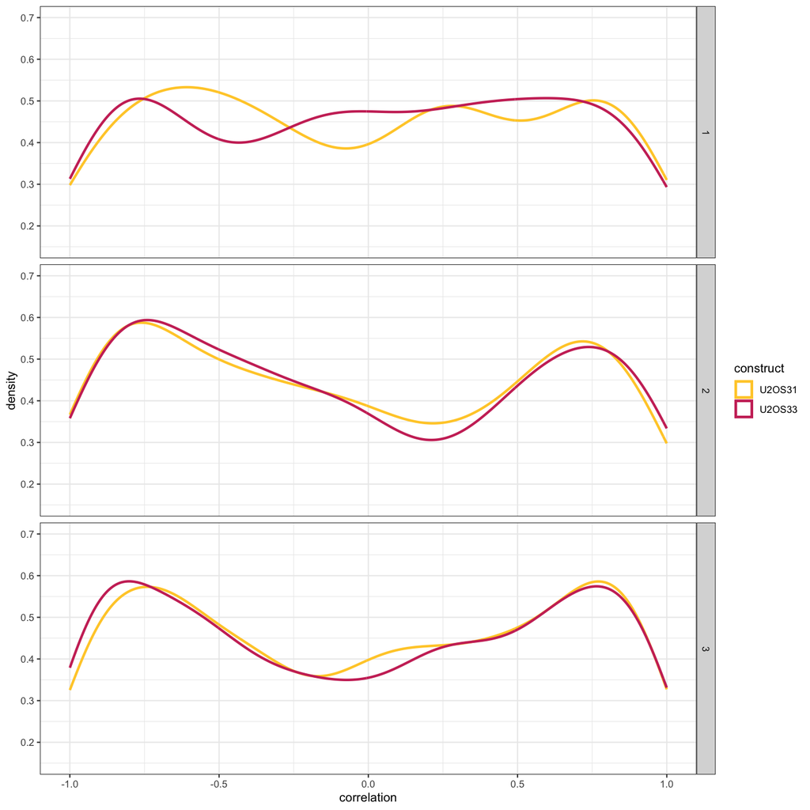

```r
> ggplot(cor.cluster) +
+   geom_density(aes(x = U2OS31, color = "U2OS31"), linewidth = 1.05) +
+   geom_density(aes(x = U2OS33, color = "U2OS33"), linewidth = 1.05) +
+   scale_color_manual(name = "construct",
+                      breaks = c("U2OS31", "U2OS33"),
+                      values = c("U2OS31" = "#FFCC33", "U2OS33" = "#CC3366")) +
+   labs(x = "correlation") +
+   coord_cartesian(ylim =  c(0.15, 0.7)) +
+   theme_bw() +
+   facet_grid(rows = cor.cluster$cluster)
```

## References - packages

- Ahlmann-Eltze C, Hickey P, Pagès H (2023). *MatrixGenerics: S4 Generic Summary Statistic Functions that Operate on Matrix-Like Objects*. doi:10.18129/B9.bioc.MatrixGenerics https://doi.org/10.18129/B9.bioc.MatrixGenerics, R package version 1.12.2, https://bioconductor.org/packages/MatrixGenerics.
- Allaire J, Xie Y, Dervieux C, McPherson J, Luraschi J, Ushey K, Atkins A, Wickham H, Cheng J, Chang W, Iannone R (2023). *rmarkdown: Dynamic Documents for R*. R package version 2.23, https://github.com/rstudio/rmarkdown. Xie Y, Allaire J, Grolemund G (2018). *R Markdown: The Definitive Guide*. Chapman and Hall/CRC, Boca Raton, Florida. ISBN 9781138359338, https://bookdown.org/yihui/rmarkdown. Xie Y, Dervieux C, Riederer E (2020). *R Markdown Cookbook*. Chapman and Hall/CRC, Boca Raton, Florida. ISBN 9780367563837, https://bookdown.org/yihui/rmarkdown-cookbook.
- Arora S, Morgan M, Carlson M, Pagès H (2023). *GenomeInfoDb: Utilities for manipulating chromosome names, including modifying them to follow a particular naming style*. doi:10.18129/B9.bioc.GenomeInfoDb https://doi.org/10.18129/B9.bioc.GenomeInfoDb, R package version 1.36.0, https://bioconductor.org/packages/GenomeInfoDb.
- Bengtsson H (2023). *matrixStats: Functions that Apply to Rows and Columns of Matrices (and to Vectors)*. R package version 1.0.0, https://CRAN.R-project.org/package=matrixStats.
- Carlson M (2023). *org.Hs.eg.db: Genome wide annotation for Human*. R package version 3.17.0.
- Huber W, Carey VJ, Gentleman R, Anders S, Carlson M, Carvalho BS, Bravo HC, Davis S, Gatto L, Girke T, Gottardo R, Hahne F, Hansen KD, Irizarry RA, Lawrence M, Love MI, MacDonald J, Obenchain V, Ole’s AK, Pag`es H, Reyes A, Shannon P, Smyth GK, Tenenbaum D, Waldron L, Morgan M (2015). “Orchestrating high-throughput genomic analysis with Bioconductor.” *Nature Methods*, *12*(2), 115-121. http://www.nature.com/nmeth/journal/v12/n2/full/nmeth.3252.html.
- Huber, W., Carey, J. V, Gentleman, R., Anders, S., Carlson, M., Carvalho, S. B, Bravo, C. H, Davis, S., Gatto, L., Girke, T., Gottardo, R., Hahne, F., Hansen, D. K, Irizarry, A. R, Lawrence, M., Love, I. M, MacDonald, J., Obenchain, V., Ole’s, K. A, Pag`es, H., Reyes, A., Shannon, P., Smyth, K. G, Tenenbaum, D., Waldron, L., Morgan, M. (2015). “Orchestrating high-throughput genomic analysis with Bioconductor.” *Nature Methods*, *12*(2), 115-121. http://www.nature.com/nmeth/journal/v12/n2/full/nmeth.3252.html.
- Lawrence M, Huber W, Pagès H, Aboyoun P, Carlson M, Gentleman R, Morgan M, Carey V (2013). “Software for Computing and Annotating Genomic Ranges.” *PLoS Computational Biology*, *9*. doi:10.1371/journal.pcbi.1003118 https://doi.org/10.1371/journal.pcbi.1003118, http://www.ploscompbiol.org/article/info%3Adoi%2F10.1371%2Fjournal.pcbi.1003118.
- Lawrence M, Huber W, Pagès H, Aboyoun P, Carlson M, Gentleman R, Morgan M, Carey V (2013). “Software for Computing and Annotating Genomic Ranges.” *PLoS Computational Biology*, *9*. doi:10.1371/journal.pcbi.1003118 https://doi.org/10.1371/journal.pcbi.1003118, http://www.ploscompbiol.org/article/info%3Adoi%2F10.1371%2Fjournal.pcbi.1003118.
- Lawrence M, Huber W, Pagès H, Aboyoun P, Carlson M, Gentleman R, Morgan M, Carey V (2013). “Software for Computing and Annotating Genomic Ranges.” *PLoS Computational Biology*, *9*. doi:10.1371/journal.pcbi.1003118 https://doi.org/10.1371/journal.pcbi.1003118, http://www.ploscompbiol.org/article/info%3Adoi%2F10.1371%2Fjournal.pcbi.1003118.
- Love MI, Huber W, Anders S (2014). “Moderated estimation of fold change and dispersion for RNA-seq data with DESeq2.” *Genome Biology*, *15*, 550. doi:10.1186/s13059-014-0550-8 https://doi.org/10.1186/s13059-014-0550-8.
- Makowski D, Lüdecke D, Patil I, Thériault R, Ben-Shachar M, Wiernik B (2023). “Automated Results Reporting as a Practical Tool to Improve Reproducibility and Methodological Best Practices Adoption.” *CRAN*. https://easystats.github.io/report/.
- Morgan M, Obenchain V, Hester J, Pagès H (2023). *SummarizedExperiment: SummarizedExperiment container*. doi:10.18129/B9.bioc.SummarizedExperiment https://doi.org/10.18129/B9.bioc.SummarizedExperiment, R package version 1.30.2, https://bioconductor.org/packages/SummarizedExperiment.
- Neuwirth E (2022). *RColorBrewer: ColorBrewer Palettes*. R package version 1.1-3, https://CRAN.R-project.org/package=RColorBrewer.
- Pagès H, Carlson M, Falcon S, Li N (2023). *AnnotationDbi: Manipulation of SQLite-based annotations in Bioconductor*. doi:10.18129/B9.bioc.AnnotationDbi https://doi.org/10.18129/B9.bioc.AnnotationDbi, R package version 1.62.1, https://bioconductor.org/packages/AnnotationDbi.
- Pagès H, Lawrence M, Aboyoun P (2023). *S4Vectors: Foundation of vector-like and list-like containers in Bioconductor*. doi:10.18129/B9.bioc.S4Vectors https://doi.org/10.18129/B9.bioc.S4Vectors, R package version 0.38.1, https://bioconductor.org/packages/S4Vectors.
- R Core Team (2023). *R: A Language and Environment for Statistical Computing*. R Foundation for Statistical Computing, Vienna, Austria. https://www.R-project.org/.
- Wickham H (2007). “Reshaping Data with the reshape Package.” *Journal of Statistical Software*, *21*(12), 1-20. http://www.jstatsoft.org/v21/i12/.
- Wickham H (2016). *ggplot2: Elegant Graphics for Data Analysis*. Springer-Verlag New York. ISBN 978-3-319-24277-4, https://ggplot2.tidyverse.org.
- Wickham H, François R, Henry L, Müller K, Vaughan D (2023). *dplyr: A Grammar of Data Manipulation*. R package version 1.1.2, https://CRAN.R-project.org/package=dplyr.
- Wu T, Hu E, Xu S, Chen M, Guo P, Dai Z, Feng T, Zhou L, Tang W, Zhan L, Fu x, Liu S, Bo X, Yu G (2021). “clusterProfiler 4.0: A universal enrichment tool for interpreting omics data.” *The Innovation*, *2*(3), 100141. doi:10.1016/j.xinn.2021.100141 https://doi.org/10.1016/j.xinn.2021.100141. Yu G, Wang L, Han Y, He Q (2012). “clusterProfiler: an R package for comparing biological themes among gene clusters.” *OMICS: A Journal of Integrative Biology*, *16*(5), 284-287. doi:10.1089/omi.2011.0118 https://doi.org/10.1089/omi.2011.0118.
- Xie Y (2023). *knitr: A General-Purpose Package for Dynamic Report Generation in R*. R package version 1.43, https://yihui.org/knitr/. Xie Y (2015). *Dynamic Documents with R and knitr*, 2nd edition. Chapman and Hall/CRC, Boca Raton, Florida. ISBN 978-1498716963, https://yihui.org/knitr/. Xie Y (2014). “knitr: A Comprehensive Tool for Reproducible Research in R.” In Stodden V, Leisch F, Peng RD (eds.), *Implementing Reproducible Computational Research*. Chapman and Hall/CRC. ISBN 978-1466561595.
- Yu G (2023). *enrichplot: Visualization of Functional Enrichment Result*. doi:10.18129/B9.bioc.enrichplot https://doi.org/10.18129/B9.bioc.enrichplot, R package version 1.20.0, https://bioconductor.org/packages/enrichplot.